# LT1_Final_Project

### Insights

The unique methodology of this study provides nuanced insights into the types of content that are typically associated with or originate from each respective country. These insights directly enhance the discussion around its motivations and problem statement, focusing on the following key areas:

##### Algorithmic Transparency and Content Strategy:

1. The study's ability to categorize singular vectors into distinct content archetypes sheds light on the YouTube algorithm's functioning, directly addressing the problem statement's concern about the platform's opaque nature. This transparency is crucial for content creators, as it allows them to understand how different content types, influenced by geographic factors, fare in the algorithm's ranking. This knowledge empowers them to tailor their content strategies more effectively to reach desired audiences.

##### Policy and Cultural Implications:

2. The findings highlight geographic biases in content distribution, informing policymakers about the need for regulations that ensure diverse and balanced content across regions. This aspect is significant for understanding the cultural impact of YouTube's content curation, as it affects the representation and visibility of various content types globally. It suggests a need for more inclusive algorithms that consider cultural diversity and regional specificity.

## Conclusion

In conclusion, this study has made its contribution to understanding YouTube's algorithm, particularly in how geographic factors influence content distribution. The two-step SVD and LSA methodology provides a clear insight into the algorithm's content categorization, addressing the challenge of its opaque nature. These findings are invaluable for content creators in strategizing for different geographic contexts, for businesses looking at YouTube as a potential digital marketing platform, and for policymakers in considering more inclusive regulations.

Furthermore, the research paves the way for future academic exploration and ethical algorithm development. It highlights the need for greater transparency in digital media algorithms and underscores the importance of understanding the underlying mechanisms that shape our digital experiences.

## Recommendations

##### Expansion of Dataset:

1. One of the primary recommendations arising from this study is the need for a more expansive dataset. To deepen and validate the findings, future research should consider incorporating a larger variety of channels and extracting more diverse features using the YouTube API. The current limitations, predominantly stemming from the dataset's scope, can be significantly mitigated by this expansion. A broader dataset would not only enhance the robustness of the analysis but also enable a more comprehensive understanding of the algorithm's nuances. This includes the exploration of additional content types, user interactions, and possibly time-based trends, which could offer a more dynamic view of how content preferences evolve over time.

##### Further Exploration:

2. Building on the initial study's insights, there is a valuable opportunity to delve deeper into geospecific factors influencing content popularity. This can include conducting detailed demographic, social, and cultural analyses to understand why certain content types are more prominent in specific zip codes or regions. Such an exploration would provide a richer context to the observed geographic biases and preferences, potentially revealing underlying social and cultural dynamics that drive content consumption patterns. This approach would not only add depth to the current understanding of YouTube's algorithm but also offer practical insights for content creators and marketers in targeting their audience more effectively. Additionally, this line of inquiry could have significant implications for academic research in media studies, sociology, and cultural anthropology, providing a unique lens through which to view digital media consumption.

### Limitations

1. Gated by resource and time constraints, the main dataset only consists of the Top 250 YouTube channels by subscriber count. This means that the study may not be able to capture the full range of channel types on YouTube and will likely have inherent biases present. Moreover, YouTube API did not have the necessary calls to return a list of channels by their subscriber counts, thus an external source was used to gather the initial list of channels.
2. Although the split SV method is designed to empower the features added in the latter stage, the study lacks a written supporting theoretical framework for the algorithm. YouTube's algorithm is also not publicly known, so the researchers could not accurately determine which features are most important for predicting the success of YouTube channels.
3. YouTube's API, platform policies, or governing algorithms may change over time, affecting the data collection process as well as the study's overall feasibility and relevance.
4. Due to the user-generated nature of YouTube channel 'keywords', clusters formed from the SVDs may require further analysis for meaningful insight generation.

## References

1. Google. YouTube Data API v3 - Google Developers. Retrieved from https://developers.google.com/youtube/v3
2. vidIQ. YouTube Stats - Top 500 YouTube Channels. Retrieved from https://vidiq.com/youtube-stats/top/500/
3. OpenAI. (2022). ChatGPT (Version 3.5) [Computer software]. Retrieved from https://www.openai.com/

## Acknowledgements

The entire thing would not have been possible without the careful guidance, understanding, and patience of the one Dr. Christian Alis.

## Appendix

Below are the different trials done using different combinations of text and non-text data.

The group opted to use the combination done in Trial 6 (detailed above in the Results & Discussion section).

### Trial 1

Text Data = Bag of Keywords only  
Non Text Data = view_count, subscriber_count, video_count, country_df, topics_df

#### SVD on Text Data

```python
text_data = bag_kw
t1_svd_text = TruncatedSVD(n_components=num_comp)
t1_text_transformed = t1_svd_text.fit_transform(text_data)
t1_var_exp = t1_svd_text.explained_variance_ratio_
t1_text_svd_components = t1_svd_text.components_.T
```

```python
t1_sv_df = pd.DataFrame(t1_text_transformed)
t1_sv_df.columns = ['SV ' + str(col) for col in range(1, t1_sv_df.shape[0]+1)]
```

```
220
```

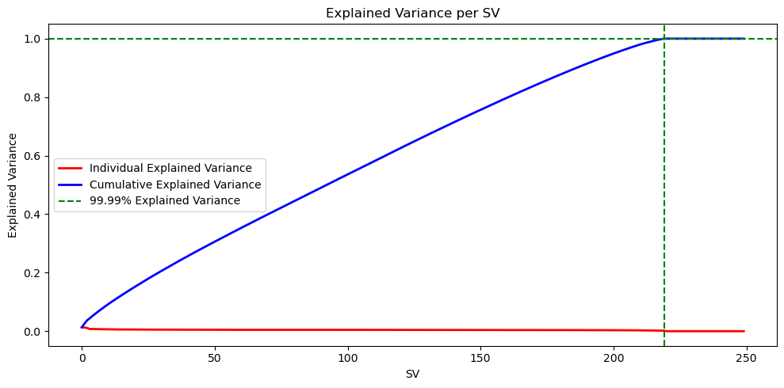

```python
plot_explained_var(t1_var_exp, 0.9999)
get_sv_num(t1_var_exp, 0.9999)
```

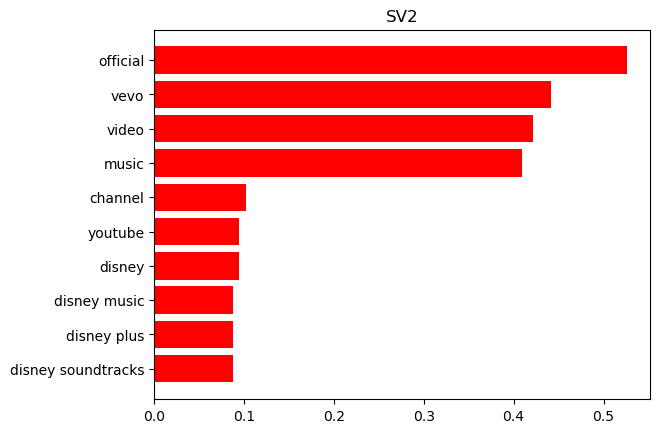

```python
plot_sv_bars(t1_text_svd_components, 3, text_data.columns)
```

[output not shown]

```python
t1_main_df = pd.concat([non_text_df,
                        country_df,
                        topics_df,
                        t1_sv_df.iloc[:, : get_sv_num(t1_var_exp, 0.9999)]],
                       axis=1)
```

```python
t1_main_df.head()
```

|  | title | view_count | subscriber_count | video_count | country_AE | country_AR | country_AU | country_BR | country_CA | country_CL | ... | SV 211 | SV 212 | SV 213 | SV 214 | SV 215 | SV 216 | SV 217 | SV 218 | SV 219 | SV 220 |
| --- | --- | --- | --- | --- | --- | --- | --- | --- | --- | --- | --- | --- | --- | --- | --- | --- | --- | --- | --- | --- | --- |
| 0 | T-Series | 238030852574 | 253000000 | 19820 | 0.0 | 0.0 | 0.0 | 0.0 | 0.0 | 0.0 | ... | -0.001849 | 0.000646 | -0.004699 | 0.000187 | -0.000620 | -0.007711 | -0.001633 | -0.009116 | 0.002465 | -0.001744 |
| 1 | MrBeast | 36996755250 | 211000000 | 767 | 0.0 | 0.0 | 0.0 | 0.0 | 0.0 | 0.0 | ... | 0.134921 | 0.142598 | 0.003925 | -0.000334 | 0.003441 | -0.008911 | 0.003116 | -0.001666 | -0.001118 | 0.000593 |
| 2 | Cocomelon - Nursery Rhymes | 170365245506 | 167000000 | 1036 | 0.0 | 0.0 | 0.0 | 0.0 | 0.0 | 0.0 | ... | -0.142744 | -0.011223 | -0.157683 | -0.001228 | 0.248852 | -0.049955 | 0.349178 | 0.044793 | 0.048504 | 0.003038 |
| 3 | SET India | 153953696545 | 165000000 | 121686 | 0.0 | 0.0 | 0.0 | 0.0 | 0.0 | 0.0 | ... | -0.000893 | -0.000351 | 0.000058 | -0.000002 | 0.000702 | 0.001578 | -0.000750 | -0.000150 | 0.000034 | 0.000243 |
| 4 | ✿ Kids Diana Show | 96980699954 | 115000000 | 1136 | 0.0 | 0.0 | 0.0 | 0.0 | 0.0 | 0.0 | ... | -0.165878 | 0.033715 | 0.003441 | -0.003507 | 0.253925 | -0.221714 | -0.300321 | 0.070819 | 0.030132 | -0.001637 |

5 rows × 288 columns

```python
t1_main_df = t1_main_df.set_index('title')
t1_main_svd = TruncatedSVD(n_components=num_comp)
t1_main_transformed = t1_main_svd.fit_transform(t1_main_df)
t1_main_var = t1_main_svd.explained_variance_ratio_
```

```
1
```

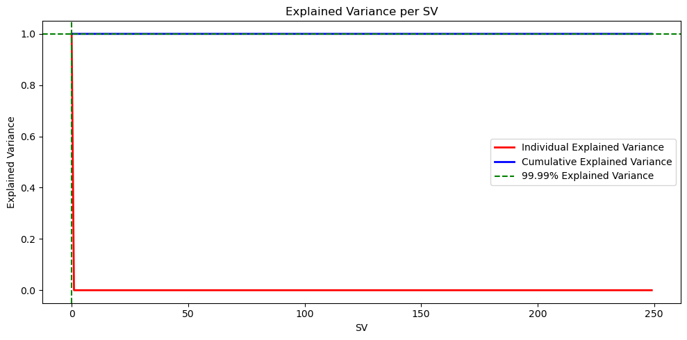

```python
plot_explained_var(t1_main_var, 0.9999)
get_sv_num(t1_main_var, 0.9999)
```

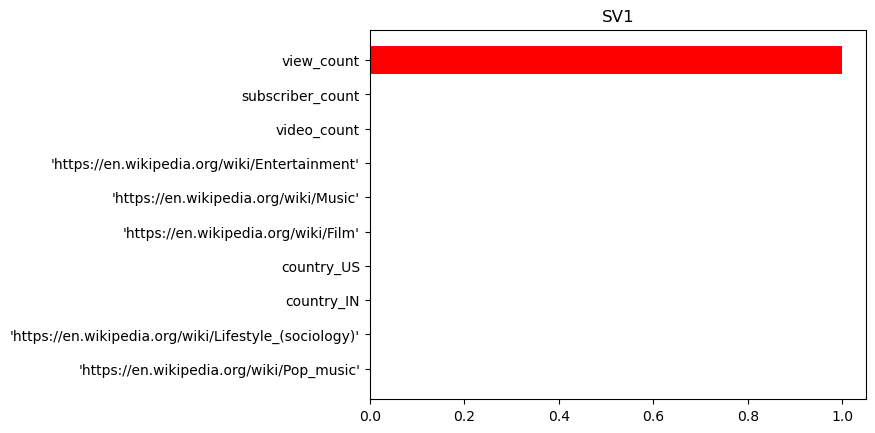

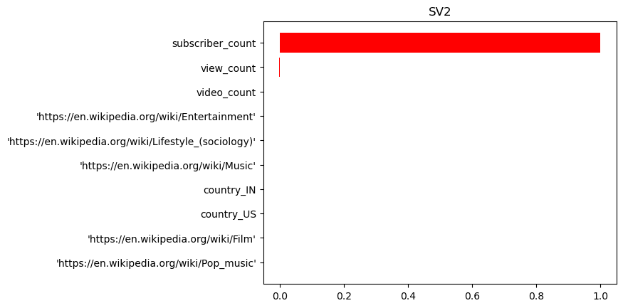

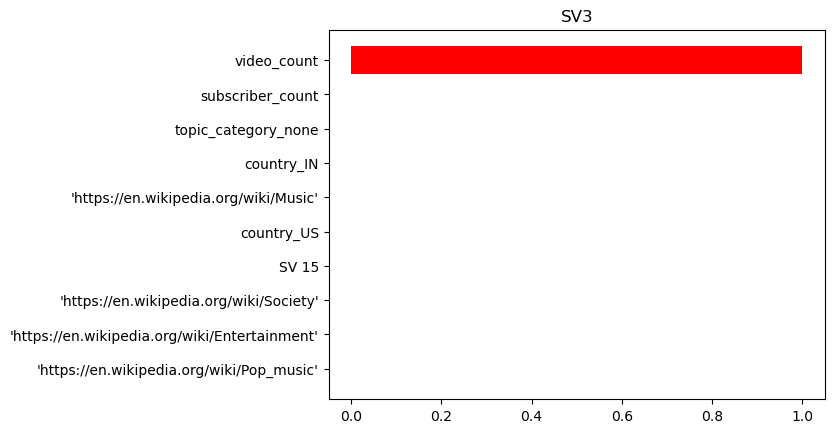

```python
plot_sv_bars(t1_main_svd.components_.T, 3, t1_main_df.columns)
```

### Trial 2

Text Data = Bag of Keywords + Topics  
Non Text Data = view_count, subscriber_count, video_count, country_df

```python
t2_text_data = pd.concat([bag_kw, topics_df], axis=1)

t2_svd_text = TruncatedSVD(n_components=num_comp)
t2_text_transformed = t2_svd_text.fit_transform(t2_text_data)
t2_var_exp = t2_svd_text.explained_variance_ratio_
t2_text_svd_components = t2_svd_text.components_.T
```

```python
t2_sv_df = pd.DataFrame(t2_text_transformed)
t2_sv_df.columns = ['SV ' + str(col) for col in range(1, t2_sv_df.shape[0]+1)]
t2_sv_df.head()
```

|  | SV 1 | SV 2 | SV 3 | SV 4 | SV 5 | SV 6 | SV 7 | SV 8 | SV 9 | SV 10 | ... | SV 241 | SV 242 | SV 243 | SV 244 | SV 245 | SV 246 | SV 247 | SV 248 | SV 249 | SV 250 |
| --- | --- | --- | --- | --- | --- | --- | --- | --- | --- | --- | --- | --- | --- | --- | --- | --- | --- | --- | --- | --- | --- |
| 0 | 0.558360 | 0.836935 | -0.181523 | 0.027835 | 0.944514 | 0.060865 | 0.257425 | 0.201718 | -0.028176 | -0.001226 | ... | 6.505213e-19 | 4.336809e-18 | -8.673617e-19 | 0.000000e+00 | 8.673617e-19 | -5.204170e-18 | 1.734723e-18 | 3.469447e-18 | -2.602085e-18 | 0.000000e+00 |
| 1 | 0.950030 | -0.458227 | 0.865145 | -0.119583 | 0.004777 | 0.227115 | -0.200039 | 0.166400 | -0.067054 | -0.003774 | ... | -4.204640e-17 | -7.209573e-18 | 1.067020e-17 | -1.681169e-17 | -1.019233e-17 | 5.705456e-19 | -1.376685e-17 | -6.439258e-18 | 6.332387e-18 | -6.631659e-18 |
| 2 | 1.579207 | 0.069197 | -0.485152 | -0.011865 | 0.125033 | -0.406724 | -0.294060 | -0.187164 | 0.034596 | 0.007460 | ... | -2.602085e-17 | -1.387779e-17 | -1.561251e-17 | 1.561251e-17 | -3.903128e-18 | 7.806256e-18 | -5.204170e-18 | 1.561251e-17 | 6.938894e-18 | 3.469447e-18 |
| 3 | 1.291293 | -0.726634 | -0.583194 | -0.041200 | -0.412005 | 0.120138 | 0.542794 | 0.061329 | -0.034508 | -0.001484 | ... | -2.515349e-17 | 8.066464e-17 | 2.081668e-17 | 1.074444e-16 | 1.734723e-17 | 1.821460e-17 | 8.673617e-18 | 4.510281e-17 | -1.040834e-17 | 2.862294e-17 |
| 4 | 0.322760 | -0.124402 | 1.075375 | -0.197898 | 0.140771 | -0.426220 | 0.513696 | -0.466395 | 0.374929 | 0.015819 | ... | 1.287416e-17 | -7.139379e-18 | 1.222349e-17 | -5.052775e-18 | 8.956237e-18 | 2.671414e-18 | 4.134375e-18 | 6.776499e-18 | -1.499954e-18 | -4.686422e-18 |

5 rows × 250 columns

```
235
```

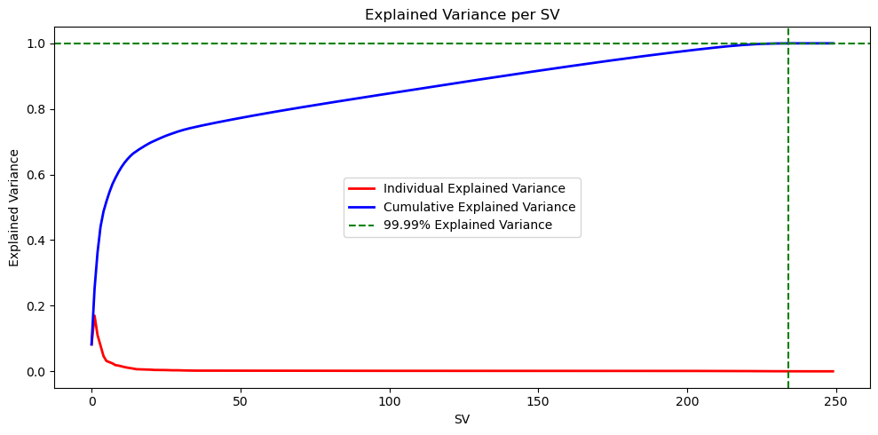

```python
plot_explained_var(t2_var_exp, 0.9999)
get_sv_num(t2_var_exp, 0.9999)
```

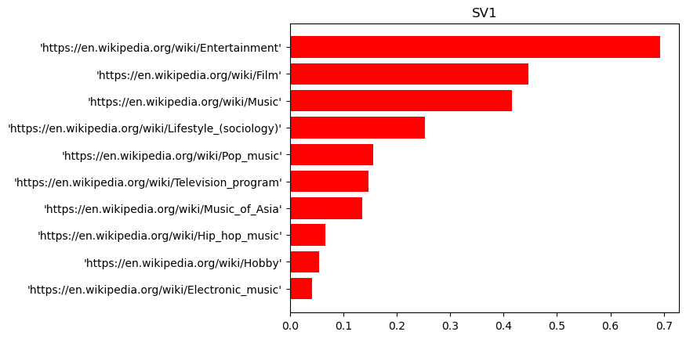

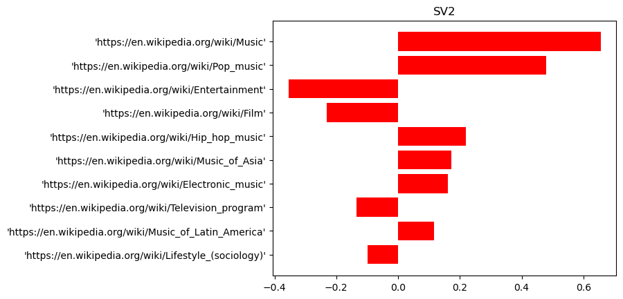

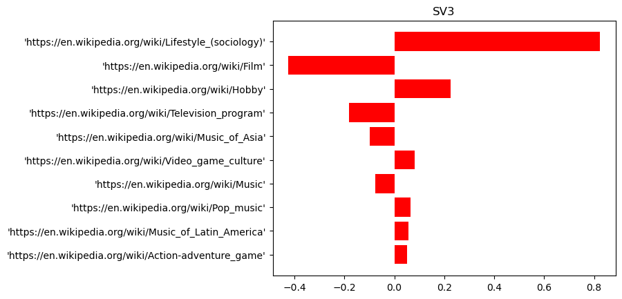

```python
plot_sv_bars(t2_text_svd_components, 3, t2_text_data.columns)
```

```python
t2_main_df = pd.concat([non_text_df,
                        country_df,
                        t2_sv_df.iloc[:, : get_sv_num(t2_var_exp, 0.9999)]],
                       axis=1)
```

```python
t2_main_df.head()
```

|  | title | view_count | subscriber_count | video_count | country_AE | country_AR | country_AU | country_BR | country_CA | country_CL | ... | SV 226 | SV 227 | SV 228 | SV 229 | SV 230 | SV 231 | SV 232 | SV 233 | SV 234 | SV 235 |
| --- | --- | --- | --- | --- | --- | --- | --- | --- | --- | --- | --- | --- | --- | --- | --- | --- | --- | --- | --- | --- | --- |
| 0 | T-Series | 238030852574 | 253000000 | 19820 | 0.0 | 0.0 | 0.0 | 0.0 | 0.0 | 0.0 | ... | -0.014763 | 0.004804 | -0.016640 | 0.000436 | 0.003943 | 0.005435 | -0.000456 | -0.001132 | 0.003761 | -0.002167 |
| 1 | MrBeast | 36996755250 | 211000000 | 767 | 0.0 | 0.0 | 0.0 | 0.0 | 0.0 | 0.0 | ... | 0.013453 | 0.017251 | 0.012502 | 0.007610 | -0.015164 | 0.013127 | -0.006207 | 0.000728 | -0.000059 | 0.000366 |
| 2 | Cocomelon - Nursery Rhymes | 170365245506 | 167000000 | 1036 | 0.0 | 0.0 | 0.0 | 0.0 | 0.0 | 0.0 | ... | 0.007589 | -0.008818 | -0.002207 | -0.000493 | 0.001170 | -0.000913 | 0.000517 | 0.002782 | -0.002130 | -0.000386 |
| 3 | SET India | 153953696545 | 165000000 | 121686 | 0.0 | 0.0 | 0.0 | 0.0 | 0.0 | 0.0 | ... | -0.006985 | 0.004001 | 0.007350 | 0.004498 | -0.005652 | -0.006085 | -0.000220 | -0.000654 | -0.000676 | -0.000677 |
| 4 | ✿ Kids Diana Show | 96980699954 | 115000000 | 1136 | 0.0 | 0.0 | 0.0 | 0.0 | 0.0 | 0.0 | ... | 0.013237 | -0.003104 | -0.020075 | 0.001672 | 0.007406 | -0.003925 | -0.002100 | -0.011667 | 0.001020 | -0.001171 |

5 rows × 267 columns

```python
t2_main_df = t2_main_df.set_index('title')
t2_main_svd = TruncatedSVD(n_components=num_comp)
t2_main_transformed = t2_main_svd.fit_transform(t2_main_df)
t2_main_var = t2_main_svd.explained_variance_ratio_
```

```
1
```

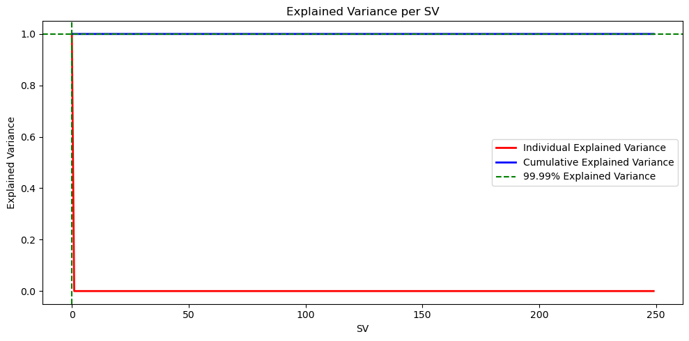

```python
plot_explained_var(t2_main_var, 0.9999)
get_sv_num(t2_main_var, 0.9999)
```

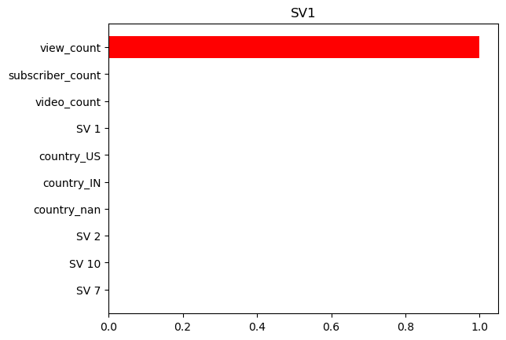

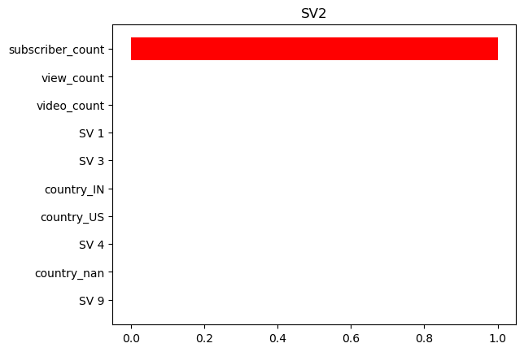

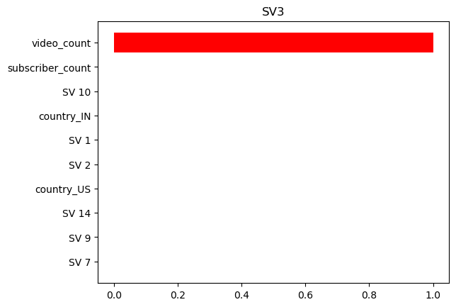

```python
plot_sv_bars(t2_main_svd.components_.T, 3, t2_main_df.columns)
```

### Trial 3

Text Data = Bag of Keywords + Topics  
Non Text Data = country_df

```python
t3_text_data = pd.concat([bag_kw, topics_df], axis=1)
t3_svd_text = TruncatedSVD(n_components=num_comp)
t3_text_transformed = t3_svd_text.fit_transform(t3_text_data)
t3_var_exp = t3_svd_text.explained_variance_ratio_
t3_text_svd_components = t3_svd_text.components_.T
```

```python
t3_sv_df = pd.DataFrame(t3_text_transformed)
t3_sv_df.columns = ['SV ' + str(col) for col in range(1, t3_sv_df.shape[0]+1)]
# t3_sv_df.head()
```

```
235
```

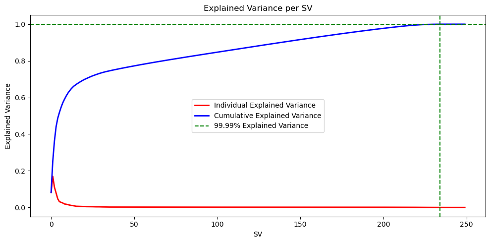

```python
plot_explained_var(t3_var_exp, 0.9999)
get_sv_num(t3_var_exp, 0.9999)
```

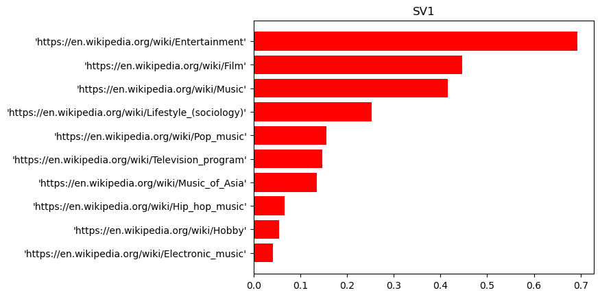

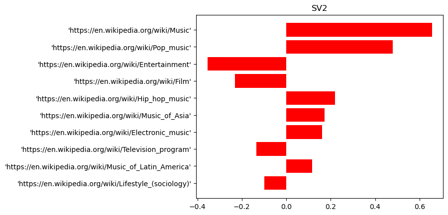

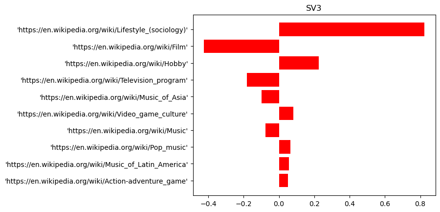

```python
plot_sv_bars(t3_text_svd_components, 3, t3_text_data.columns)
```

```python
t3_main_df = pd.concat([non_text_df['title'],
                        country_df,
                        t3_sv_df.iloc[:, : get_sv_num(t3_var_exp, 0.9999)]],
                       axis=1)
```

```python
t3_main_df
t3_main_df.head()
```

|  | title | country_AE | country_AR | country_AU | country_BR | country_CA | country_CL | country_CO | country_DE | country_ES | ... | SV 226 | SV 227 | SV 228 | SV 229 | SV 230 | SV 231 | SV 232 | SV 233 | SV 234 | SV 235 |
| --- | --- | --- | --- | --- | --- | --- | --- | --- | --- | --- | --- | --- | --- | --- | --- | --- | --- | --- | --- | --- | --- |
| 0 | T-Series | 0.0 | 0.0 | 0.0 | 0.0 | 0.0 | 0.0 | 0.0 | 0.0 | 0.0 | ... | -0.014763 | 0.004804 | -0.016640 | 0.000436 | 0.003943 | 0.005435 | -0.000456 | -0.001132 | 0.003761 | -0.002167 |
| 1 | MrBeast | 0.0 | 0.0 | 0.0 | 0.0 | 0.0 | 0.0 | 0.0 | 0.0 | 0.0 | ... | 0.013453 | 0.017251 | 0.012502 | 0.007610 | -0.015164 | 0.013127 | -0.006207 | 0.000728 | -0.000059 | 0.000366 |
| 2 | Cocomelon - Nursery Rhymes | 0.0 | 0.0 | 0.0 | 0.0 | 0.0 | 0.0 | 0.0 | 0.0 | 0.0 | ... | 0.007589 | -0.008818 | -0.002207 | -0.000493 | 0.001170 | -0.000913 | 0.000517 | 0.002782 | -0.002130 | -0.000386 |
| 3 | SET India | 0.0 | 0.0 | 0.0 | 0.0 | 0.0 | 0.0 | 0.0 | 0.0 | 0.0 | ... | -0.006985 | 0.004001 | 0.007350 | 0.004498 | -0.005652 | -0.006085 | -0.000220 | -0.000654 | -0.000676 | -0.000677 |
| 4 | ✿ Kids Diana Show | 0.0 | 0.0 | 0.0 | 0.0 | 0.0 | 0.0 | 0.0 | 0.0 | 0.0 | ... | 0.013237 | -0.003104 | -0.020075 | 0.001672 | 0.007406 | -0.003925 | -0.002100 | -0.011667 | 0.001020 | -0.001171 |

5 rows × 264 columns

```python
t3_main_df = t3_main_df.set_index('title')
t3_main_svd = TruncatedSVD(n_components=num_comp)
t3_main_transformed = t3_main_svd.fit_transform(t3_main_df)
t3_main_var = t3_main_svd.explained_variance_ratio_
```

```
239
```

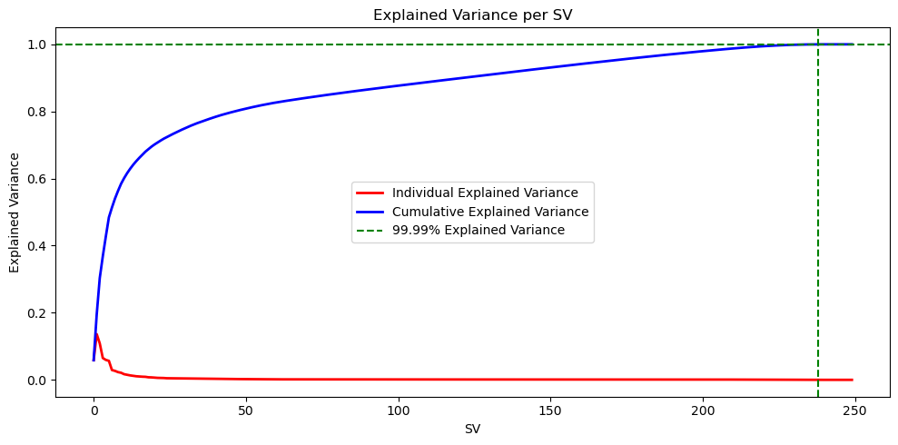

```python
plot_explained_var(t3_main_var, 0.9999)
get_sv_num(t3_main_var, 0.9999)
```

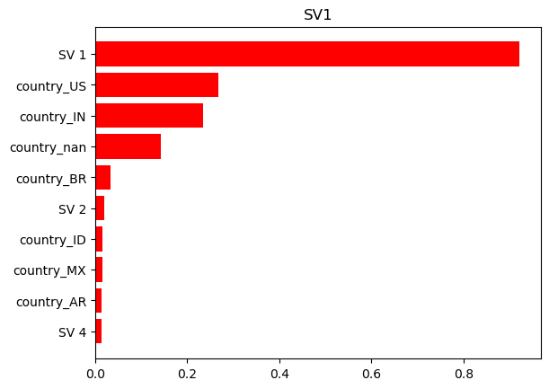

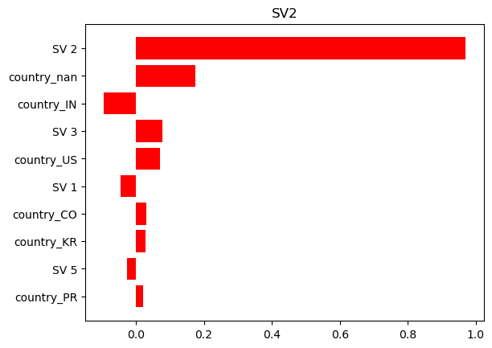

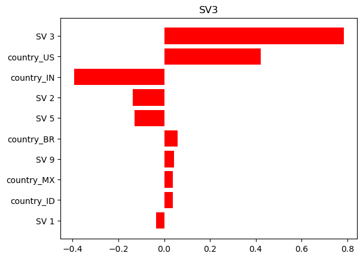

```python
plot_sv_bars(t3_main_svd.components_.T, 3, t3_main_df.columns)
```

### Trial 4

Text Data = Bag of Keywords + Topics + country_df  
Non Text Data = view_count, subscriber_count, video_count

```python
t4_text_data = pd.concat([bag_kw, country_df, topics_df], axis=1)

t4_svd_text = TruncatedSVD(n_components=num_comp)
t4_text_transformed = t4_svd_text.fit_transform(t4_text_data)
t4_var_exp = t4_svd_text.explained_variance_ratio_
t4_text_svd_components = t4_svd_text.components_.T
```

```python
t4_sv_df = pd.DataFrame(t4_text_transformed)
t4_sv_df.columns = ['SV ' + str(col) for col in range(1, t4_sv_df.shape[0]+1)]
# t4_sv_df.head()
```

```
239
```

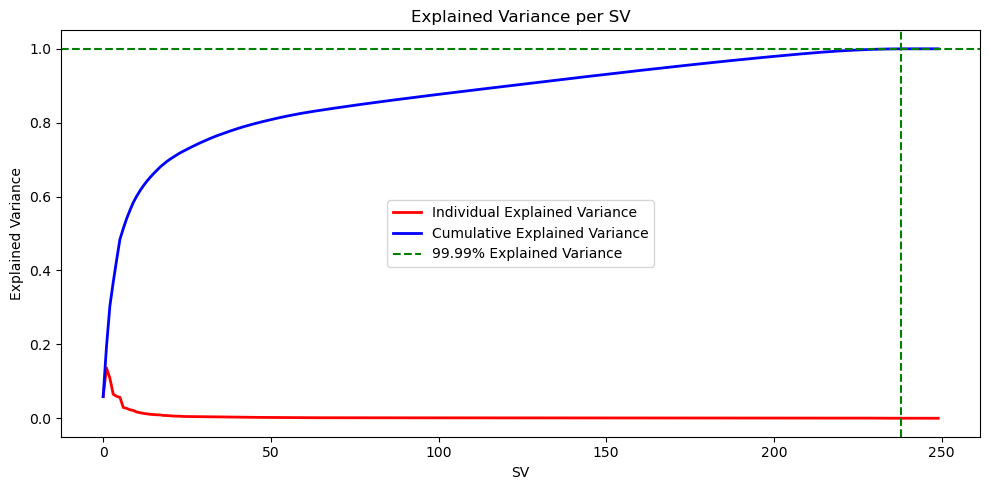

```python
plot_explained_var(t4_var_exp, 0.9999)
get_sv_num(t4_var_exp, 0.9999)
```

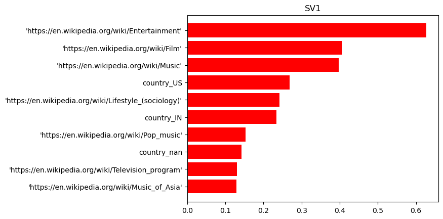

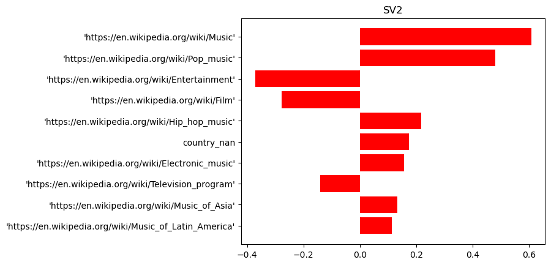

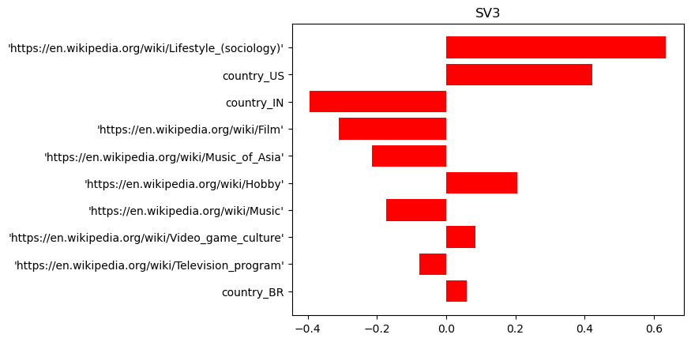

```python
plot_sv_bars(t4_text_svd_components, 3, t4_text_data.columns)
```

```python
t4_main_df = pd.concat([non_text_df,
                        t4_sv_df.iloc[:, : get_sv_num(t4_var_exp, 0.9999)]],
                       axis=1)
```

```python
t4_main_df
t4_main_df.head()
```

|  | title | view_count | subscriber_count | video_count | SV 1 | SV 2 | SV 3 | SV 4 | SV 5 | SV 6 | ... | SV 230 | SV 231 | SV 232 | SV 233 | SV 234 | SV 235 | SV 236 | SV 237 | SV 238 | SV 239 |
| --- | --- | --- | --- | --- | --- | --- | --- | --- | --- | --- | --- | --- | --- | --- | --- | --- | --- | --- | --- | --- | --- |
| 0 | T-Series | 238030852574 | 253000000 | 19820 | 0.766724 | 0.649898 | -0.796948 | -0.096070 | 0.789457 | -0.680058 | ... | 0.012649 | 0.012938 | -0.003761 | 0.003248 | -0.003750 | 0.004813 | 0.001706 | -0.000042 | -0.000805 | -0.000703 |
| 1 | MrBeast | 36996755250 | 211000000 | 767 | 1.141784 | -0.351488 | 1.114155 | -0.077682 | -0.015061 | -0.241776 | ... | -0.019058 | -0.027055 | 0.006467 | -0.018437 | -0.028633 | 0.011902 | 0.003319 | -0.001067 | 0.001349 | 0.000750 |
| 2 | Cocomelon - Nursery Rhymes | 170365245506 | 167000000 | 1036 | 1.720927 | 0.024931 | -0.014287 | 0.372070 | -0.699678 | -0.312932 | ... | 0.001757 | 0.001763 | -0.004276 | -0.007403 | -0.005425 | 0.001163 | -0.002387 | -0.001329 | 0.003752 | -0.002084 |
| 3 | SET India | 153953696545 | 165000000 | 121686 | 1.402036 | -0.894161 | -0.742773 | 0.032171 | -0.069220 | -0.040410 | ... | -0.000131 | -0.003283 | 0.002105 | 0.000960 | 0.004035 | -0.005898 | -0.000198 | 0.008047 | 0.002840 | 0.000717 |
| 4 | ✿ Kids Diana Show | 96980699954 | 115000000 | 1136 | 0.583777 | 0.015265 | 1.290893 | -0.032988 | 0.033700 | -0.678172 | ... | 0.006557 | 0.001413 | -0.005211 | 0.007128 | 0.003646 | 0.005081 | -0.012987 | 0.002730 | -0.011079 | -0.003364 |

5 rows × 243 columns

```python
t4_main_df = t4_main_df.set_index('title')
t4_main_svd = TruncatedSVD(n_components=242)  # 242 because columns are shorter
t4_main_transformed = t4_main_svd.fit_transform(t4_main_df)
t4_main_var = t4_main_svd.explained_variance_ratio_
```

```
1
```

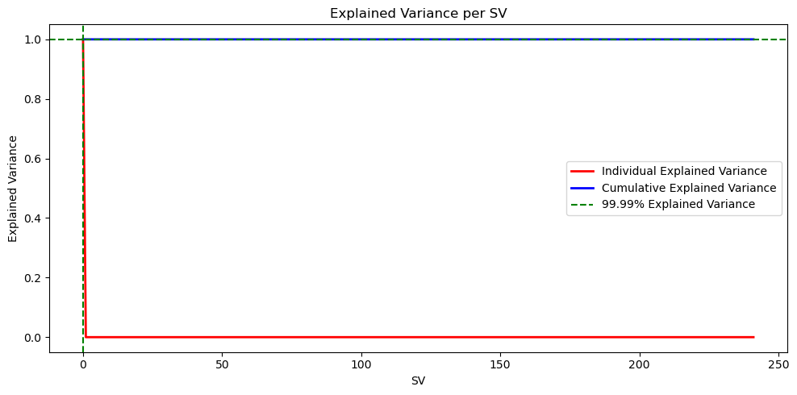

```python
plot_explained_var(t4_main_var, 0.9999)
get_sv_num(t4_main_var, 0.9999)
```

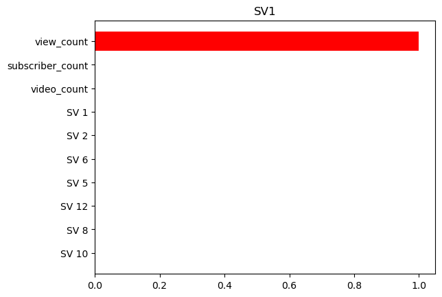

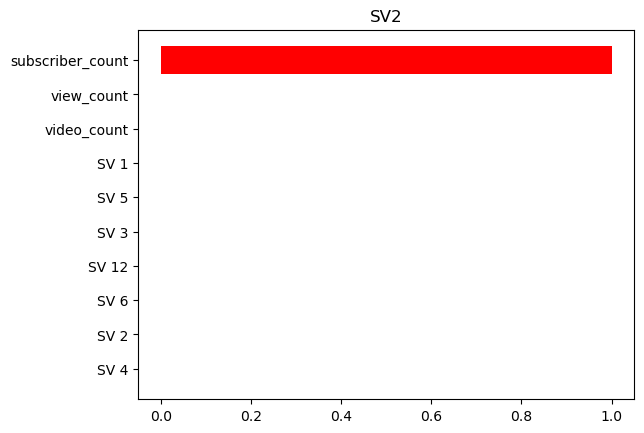

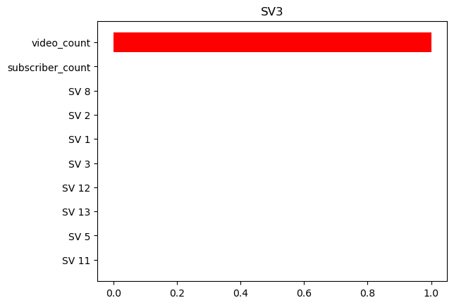

```python
plot_sv_bars(t4_main_svd.components_.T, 3, t4_main_df.columns)
```

### Trial 5

Text Data = Bag of Keywords + Topics + country_df  
Non Text Data = normalized(view_count, subscriber_count, video_count)

```python
t5_text_data = pd.concat([bag_kw, country_df, topics_df], axis=1)

t5_svd_text = TruncatedSVD(n_components=num_comp)
t5_text_transformed = t5_svd_text.fit_transform(t5_text_data)
t5_var_exp = t5_svd_text.explained_variance_ratio_
t5_text_svd_components = t5_svd_text.components_.T
```

```python
t5_sv_df = pd.DataFrame(t5_text_transformed)
t5_sv_df.columns = ['SV ' + str(col) for col in range(1, t5_sv_df.shape[0]+1)]
t5_sv_df.head()
```

|  | SV 1 | SV 2 | SV 3 | SV 4 | SV 5 | SV 6 | SV 7 | SV 8 | SV 9 | SV 10 | ... | SV 241 | SV 242 | SV 243 | SV 244 | SV 245 | SV 246 | SV 247 | SV 248 | SV 249 | SV 250 |
| --- | --- | --- | --- | --- | --- | --- | --- | --- | --- | --- | --- | --- | --- | --- | --- | --- | --- | --- | --- | --- | --- |
| 0 | 0.766724 | 0.649898 | -0.796948 | -0.096070 | 0.789457 | -0.680058 | -0.402876 | -0.165396 | 0.172776 | 0.243209 | ... | 0.001569 | 0.000209 | -2.168404e-18 | 1.734723e-18 | -1.734723e-18 | -3.469447e-18 | 1.192622e-18 | -1.734723e-18 | -3.469447e-18 | 0.000000e+00 |
| 1 | 1.141784 | -0.351488 | 1.114155 | -0.077682 | -0.015061 | -0.241776 | -0.094766 | -0.037880 | 0.171744 | -0.252136 | ... | -0.000043 | -0.000110 | 1.951564e-17 | 8.673617e-18 | 6.505213e-18 | 4.510281e-17 | 3.295975e-17 | 3.122502e-17 | -1.734723e-17 | -1.462155e-15 |
| 2 | 1.720927 | 0.024931 | -0.014287 | 0.372070 | -0.699678 | -0.312932 | -0.221126 | -0.330578 | -0.431302 | -0.184585 | ... | 0.000850 | -0.000110 | 3.209238e-17 | 2.081668e-17 | 6.938894e-18 | -1.040834e-17 | 0.000000e+00 | 5.204170e-18 | 8.673617e-18 | 5.551115e-17 |
| 3 | 1.402036 | -0.894161 | -0.742773 | 0.032171 | -0.069220 | -0.040410 | 0.271934 | 0.524499 | 0.375249 | 0.333490 | ... | 0.000151 | 0.000159 | -3.469447e-17 | -3.599551e-17 | -6.938894e-18 | -5.030698e-17 | 8.673617e-18 | -4.857226e-17 | 1.040834e-17 | -4.319461e-16 |
| 4 | 0.583777 | 0.015265 | 1.290893 | -0.032988 | 0.033700 | -0.678172 | -0.450830 | 0.358828 | -0.149650 | 0.219577 | ... | -0.000162 | 0.000667 | -9.486769e-17 | -1.092334e-17 | -6.234162e-18 | -5.963112e-18 | -4.694595e-17 | -1.512462e-17 | -1.496199e-17 | -1.095641e-15 |

5 rows × 250 columns

```
239
```

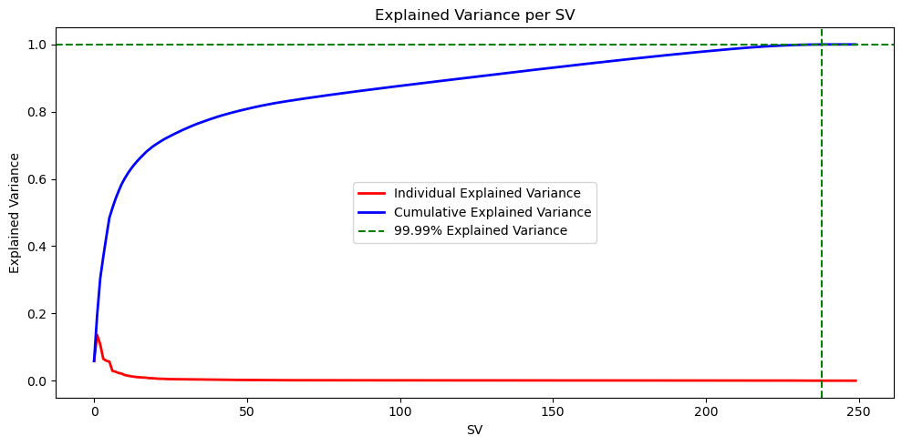

```python
plot_explained_var(t5_var_exp, 0.9999)
get_sv_num(t5_var_exp, 0.9999)
```

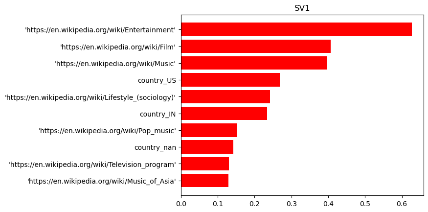

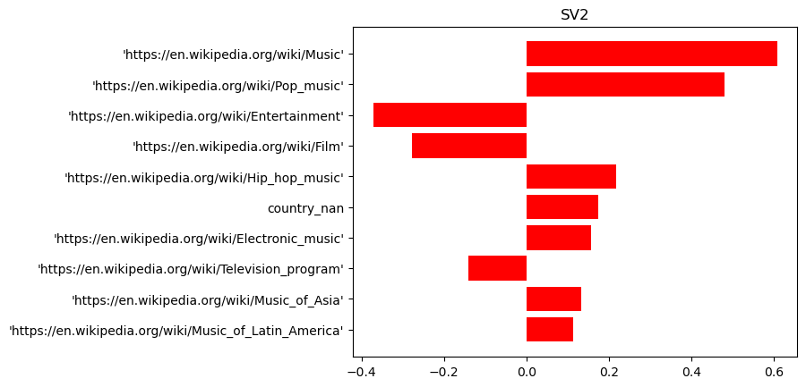

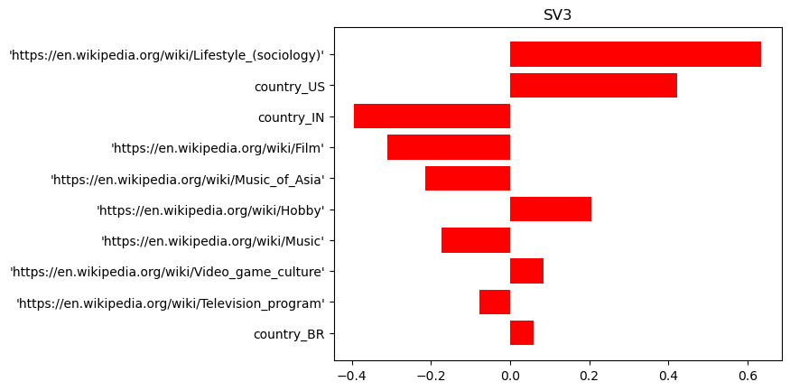

```python
plot_sv_bars(t5_text_svd_components, 3, t5_text_data.columns)
```

```python
t5_non_text_df = non_text_df.copy()
t5_non_text_df['view_count'] = (t5_non_text_df['view_count'] /
                                non_text_df['view_count'].max())
t5_non_text_df['subscriber_count'] = (t5_non_text_df['subscriber_count'] /
                                      non_text_df['subscriber_count'].max())
t5_non_text_df['video_count'] = (t5_non_text_df['video_count'] /
                                 non_text_df['video_count'].max())
```

```python
t5_main_df = pd.concat([t5_non_text_df,
                        t5_sv_df.iloc[:, : get_sv_num(t5_var_exp, 0.9999)]],
                       axis=1)
```

```python
t5_main_df.head()
```

|  | title | view_count | subscriber_count | video_count | SV 1 | SV 2 | SV 3 | SV 4 | SV 5 | SV 6 | ... | SV 230 | SV 231 | SV 232 | SV 233 | SV 234 | SV 235 | SV 236 | SV 237 | SV 238 | SV 239 |
| --- | --- | --- | --- | --- | --- | --- | --- | --- | --- | --- | --- | --- | --- | --- | --- | --- | --- | --- | --- | --- | --- |
| 0 | T-Series | 1.000000 | 1.000000 | 0.059853 | 0.766724 | 0.649898 | -0.796948 | -0.096070 | 0.789457 | -0.680058 | ... | 0.012649 | 0.012938 | -0.003761 | 0.003248 | -0.003750 | 0.004813 | 0.001706 | -0.000042 | -0.000805 | -0.000703 |
| 1 | MrBeast | 0.155428 | 0.833992 | 0.002316 | 1.141784 | -0.351488 | 1.114155 | -0.077682 | -0.015061 | -0.241776 | ... | -0.019058 | -0.027055 | 0.006467 | -0.018437 | -0.028633 | 0.011902 | 0.003319 | -0.001067 | 0.001349 | 0.000750 |
| 2 | Cocomelon - Nursery Rhymes | 0.715728 | 0.660079 | 0.003129 | 1.720927 | 0.024931 | -0.014287 | 0.372070 | -0.699678 | -0.312932 | ... | 0.001757 | 0.001763 | -0.004276 | -0.007403 | -0.005425 | 0.001163 | -0.002387 | -0.001329 | 0.003752 | -0.002084 |
| 3 | SET India | 0.646780 | 0.652174 | 0.367474 | 1.402036 | -0.894161 | -0.742773 | 0.032171 | -0.069220 | -0.040410 | ... | -0.000131 | -0.003283 | 0.002105 | 0.000960 | 0.004035 | -0.005898 | -0.000198 | 0.008047 | 0.002840 | 0.000717 |
| 4 | ✿ Kids Diana Show | 0.407429 | 0.454545 | 0.003431 | 0.583777 | 0.015265 | 1.290893 | -0.032988 | 0.033700 | -0.678172 | ... | 0.006557 | 0.001413 | -0.005211 | 0.007128 | 0.003646 | 0.005081 | -0.012987 | 0.002730 | -0.011079 | -0.003364 |

5 rows × 243 columns

```python
t5_main_df = t5_main_df.set_index('title')
t5_main_svd = TruncatedSVD(n_components=242)  # 242 because columns are shorter
t5_main_transformed = t5_main_svd.fit_transform(t5_main_df)
t5_main_var = t5_main_svd.explained_variance_ratio_
```

```
238
```

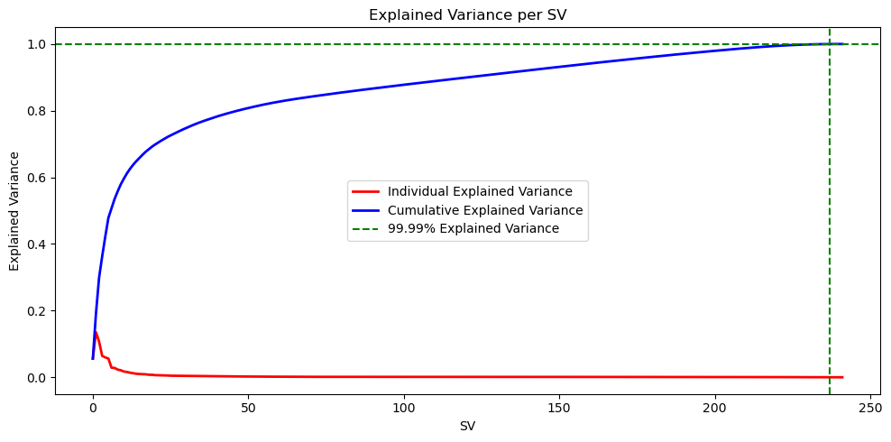

```python
plot_explained_var(t5_main_var, 0.9999)
get_sv_num(t5_main_var, 0.9999)
```

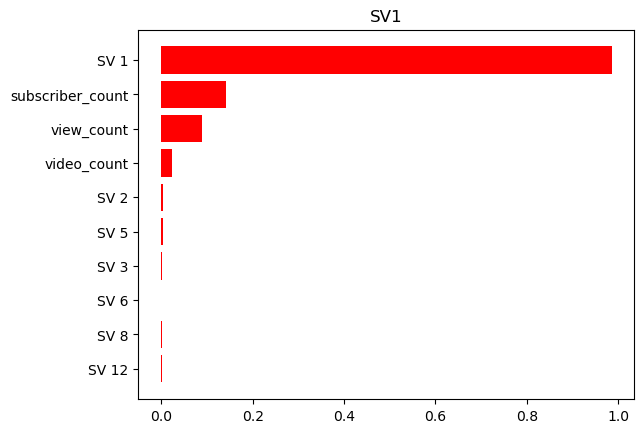

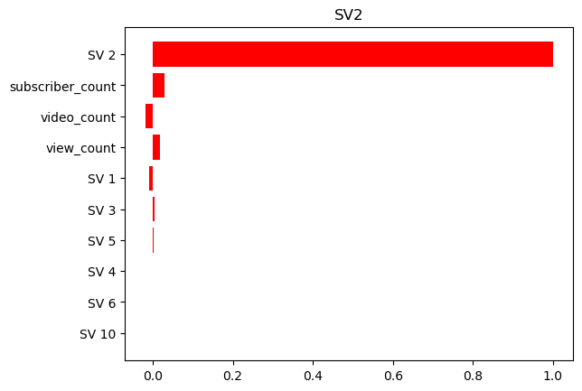

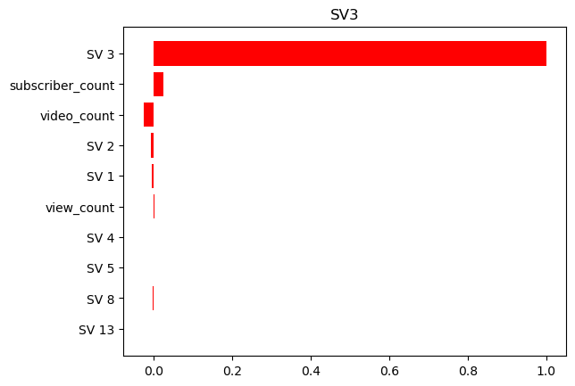

```python
plot_sv_bars(t5_main_svd.components_.T, 3, t5_main_df.columns)
```

### Trial 7

Text Data = Bag of Keywords  
Non Text Data = country_df + normalized metrics

```python
t7_text_data = bag_kw

t7_svd_text = TruncatedSVD(n_components=num_comp)
t7_text_transformed = t7_svd_text.fit_transform(t7_text_data)
t7_var_exp = t7_svd_text.explained_variance_ratio_
t7_text_svd_components = t7_svd_text.components_.T
```

```python
t7_sv_df = pd.DataFrame(t7_text_transformed)
t7_sv_df.columns = ['SV ' + str(col) for col in range(1, t7_sv_df.shape[0]+1)]
# t7_sv_df.head()
```

```
220
```

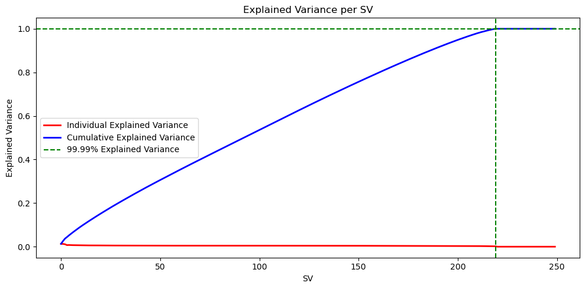

```python
plot_explained_var(t7_var_exp, 0.9999)
get_sv_num(t7_var_exp, 0.9999)
```

```python
plot_sv_bars(t7_text_svd_components, 3, t7_text_data.columns)
```

[output not shown]

```python
t7_non_text_df = non_text_df.copy()
t7_non_text_df['view_count'] = (t7_non_text_df['view_count'] /
                                non_text_df['view_count'].max())
t7_non_text_df['subscriber_count'] = (t7_non_text_df['subscriber_count'] /
                                      non_text_df['subscriber_count'].max())
t7_non_text_df['video_count'] = (t7_non_text_df['video_count'] /
                                 non_text_df['video_count'].max())
```

```python
t7_main_df = pd.concat([t7_non_text_df,
                        country_df,
                        t6_sv_df.iloc[:, : get_sv_num(t7_var_exp, 0.9999)]],
                       axis=1)
```

```python
t7_main_df
t7_main_df.head()
```

|  | title | view_count | subscriber_count | video_count | country_AE | country_AR | country_AU | country_BR | country_CA | country_CL | ... | SV 211 | SV 212 | SV 213 | SV 214 | SV 215 | SV 216 | SV 217 | SV 218 | SV 219 | SV 220 |
| --- | --- | --- | --- | --- | --- | --- | --- | --- | --- | --- | --- | --- | --- | --- | --- | --- | --- | --- | --- | --- | --- |
| 0 | T-Series | 1.000000 | 1.000000 | 0.059853 | 0.0 | 0.0 | 0.0 | 0.0 | 0.0 | 0.0 | ... | -0.001849 | 0.000646 | -0.004699 | 0.000187 | -0.000620 | -0.007711 | -0.001633 | -0.009116 | 0.002465 | -0.001744 |
| 1 | MrBeast | 0.155428 | 0.833992 | 0.002316 | 0.0 | 0.0 | 0.0 | 0.0 | 0.0 | 0.0 | ... | 0.134921 | 0.142598 | 0.003925 | -0.000334 | 0.003441 | -0.008911 | 0.003116 | -0.001666 | -0.001118 | 0.000593 |
| 2 | Cocomelon - Nursery Rhymes | 0.715728 | 0.660079 | 0.003129 | 0.0 | 0.0 | 0.0 | 0.0 | 0.0 | 0.0 | ... | -0.142744 | -0.011223 | -0.157683 | -0.001228 | 0.248852 | -0.049955 | 0.349178 | 0.044793 | 0.048504 | 0.003038 |
| 3 | SET India | 0.646780 | 0.652174 | 0.367474 | 0.0 | 0.0 | 0.0 | 0.0 | 0.0 | 0.0 | ... | -0.000893 | -0.000351 | 0.000058 | -0.000002 | 0.000702 | 0.001578 | -0.000750 | -0.000150 | 0.000034 | 0.000243 |
| 4 | ✿ Kids Diana Show | 0.407429 | 0.454545 | 0.003431 | 0.0 | 0.0 | 0.0 | 0.0 | 0.0 | 0.0 | ... | -0.165878 | 0.033715 | 0.003441 | -0.003507 | 0.253925 | -0.221714 | -0.300321 | 0.070819 | 0.030132 | -0.001637 |

5 rows × 252 columns

```python
t7_main_df = t7_main_df.set_index('title')
t7_main_svd = TruncatedSVD(n_components=num_comp)
t7_main_transformed = t7_main_svd.fit_transform(t7_main_df)
t7_main_var = t7_main_svd.explained_variance_ratio_
```

```
230
```

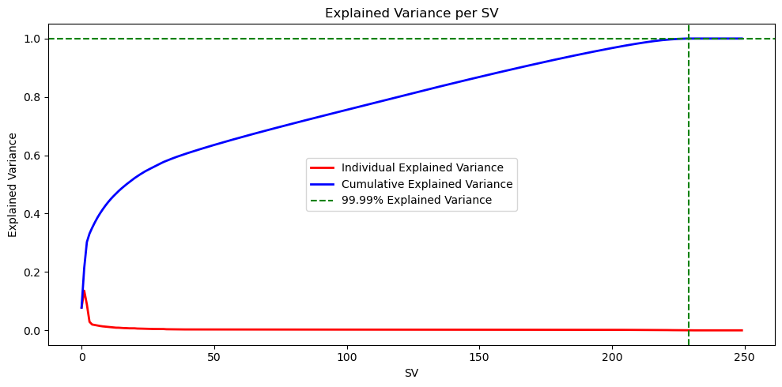

```python
plot_explained_var(t7_main_var, 0.9999)
get_sv_num(t7_main_var, 0.9999)
```

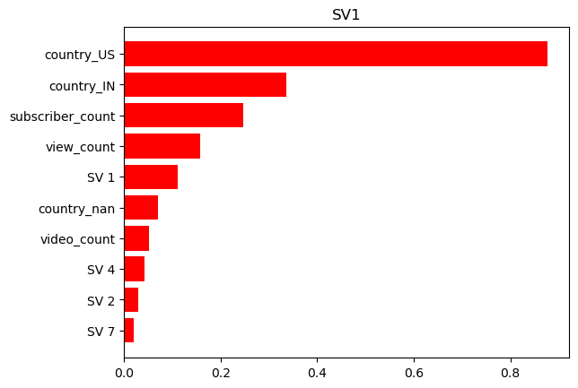

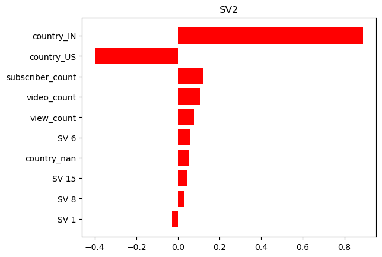

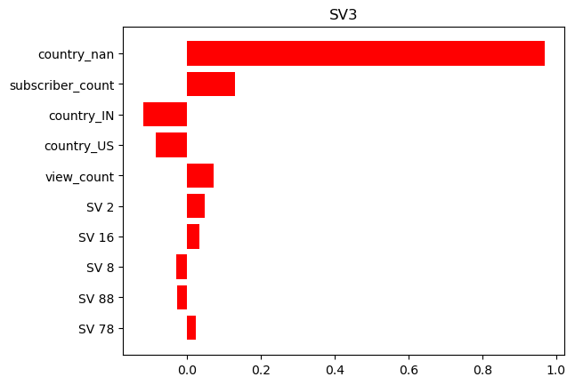

```python
plot_sv_bars(t7_main_svd.components_.T, 3, t7_main_df.columns)
```

### Trial 8

Text Data = Bag of Keywords  
Non Text Data = country_df + vid_count_normed

```python
t8_text_data = bag_kw
t8_svd_text = TruncatedSVD(n_components=num_comp)
t8_text_transformed = t8_svd_text.fit_transform(t8_text_data)
t8_var_exp = t8_svd_text.explained_variance_ratio_
t8_text_svd_components = t8_svd_text.components_.T
```

```python
t8_sv_df = pd.DataFrame(t8_text_transformed)
t8_sv_df.columns = ['SV ' + str(col) for col in range(1, t8_sv_df.shape[0]+1)]
# t6_sv_df.head()
```

```
220
```

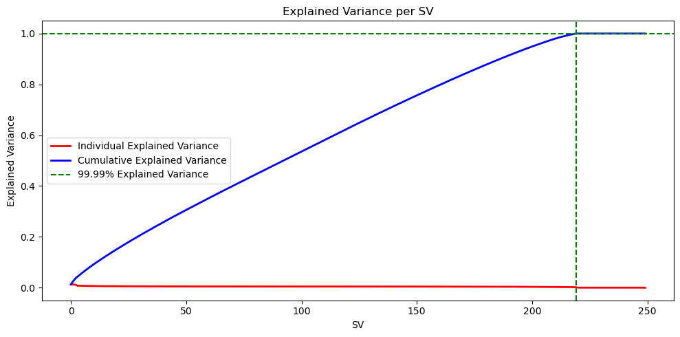

```python
plot_explained_var(t8_var_exp, 0.9999)
get_sv_num(t8_var_exp, 0.9999)
```

```python
plot_sv_bars(t8_text_svd_components, 3, t8_text_data.columns)
```

[output not shown]

```python
t8_non_text_df = non_text_df.copy()
t8_non_text_df['view_count'] = (t8_non_text_df['view_count'] /
                                non_text_df['view_count'].max())
t8_non_text_df['subscriber_count'] = (t8_non_text_df['subscriber_count'] /
                                      non_text_df['subscriber_count'].max())
t8_non_text_df['video_count'] = (t8_non_text_df['video_count'] /
                                 non_text_df['video_count'].max())

t8_main_df = pd.concat([t8_non_text_df[['title', 'video_count']],
                        country_df/5,
                        t8_sv_df.iloc[:, : get_sv_num(t8_var_exp, 0.9999)] ],
                       axis=1)
```

```python
t8_main_df.head()
```

|  | title | video_count | country_AE | country_AR | country_AU | country_BR | country_CA | country_CL | country_CO | country_DE | ... | SV 211 | SV 212 | SV 213 | SV 214 | SV 215 | SV 216 | SV 217 | SV 218 | SV 219 | SV 220 |
| --- | --- | --- | --- | --- | --- | --- | --- | --- | --- | --- | --- | --- | --- | --- | --- | --- | --- | --- | --- | --- | --- |
| 0 | T-Series | 0.059853 | 0.0 | 0.0 | 0.0 | 0.0 | 0.0 | 0.0 | 0.0 | 0.0 | ... | -0.001849 | 0.000646 | -0.004699 | 0.000187 | -0.000620 | -0.007711 | -0.001633 | -0.009116 | 0.002465 | -0.001744 |
| 1 | MrBeast | 0.002316 | 0.0 | 0.0 | 0.0 | 0.0 | 0.0 | 0.0 | 0.0 | 0.0 | ... | 0.134921 | 0.142598 | 0.003925 | -0.000334 | 0.003441 | -0.008911 | 0.003116 | -0.001666 | -0.001118 | 0.000593 |
| 2 | Cocomelon - Nursery Rhymes | 0.003129 | 0.0 | 0.0 | 0.0 | 0.0 | 0.0 | 0.0 | 0.0 | 0.0 | ... | -0.142744 | -0.011223 | -0.157683 | -0.001228 | 0.248852 | -0.049955 | 0.349178 | 0.044793 | 0.048504 | 0.003038 |
| 3 | SET India | 0.367474 | 0.0 | 0.0 | 0.0 | 0.0 | 0.0 | 0.0 | 0.0 | 0.0 | ... | -0.000893 | -0.000351 | 0.000058 | -0.000002 | 0.000702 | 0.001578 | -0.000750 | -0.000150 | 0.000034 | 0.000243 |
| 4 | ✿ Kids Diana Show | 0.003431 | 0.0 | 0.0 | 0.0 | 0.0 | 0.0 | 0.0 | 0.0 | 0.0 | ... | -0.165878 | 0.033715 | 0.003441 | -0.003507 | 0.253925 | -0.221714 | -0.300321 | 0.070819 | 0.030132 | -0.001637 |

5 rows × 250 columns

```python
t8_main_df = t8_main_df.set_index('title')
t8_main_svd = TruncatedSVD(n_components=249) # 249 because columns are shorter
t8_main_transformed = t8_main_svd.fit_transform(t8_main_df)
t8_main_var = t8_main_svd.explained_variance_ratio_
```

```
230
```

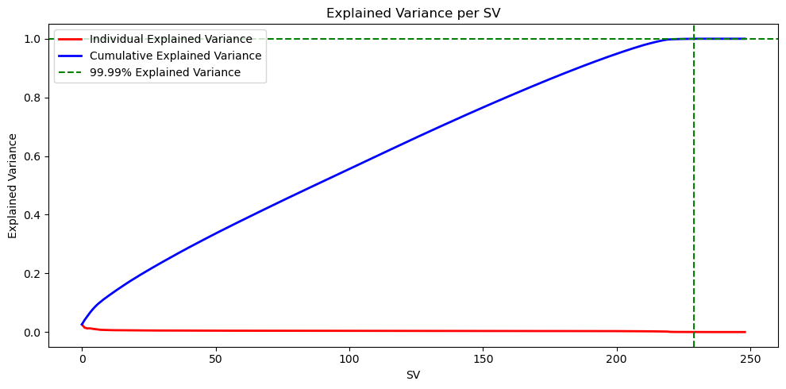

```python
plot_explained_var(t8_main_var, 0.9999)
get_sv_num(t8_main_var, 0.9999)
```

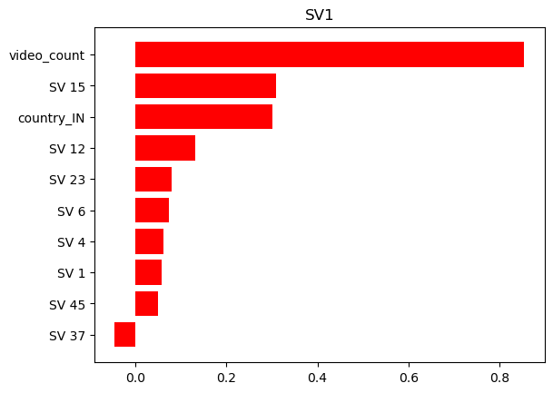

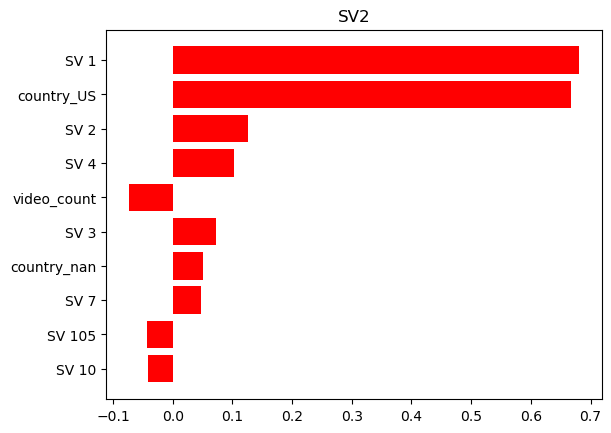

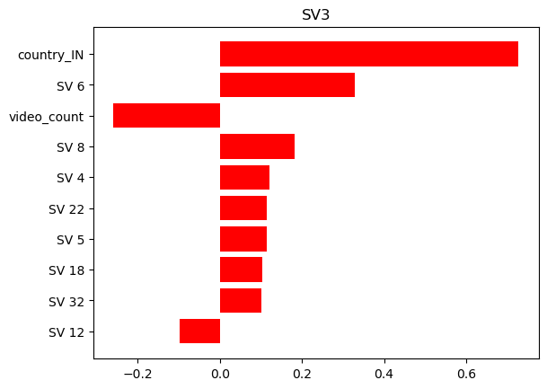

```python
plot_sv_bars(t8_main_svd.components_.T, 3, t8_main_df.columns)
```